# Mapping regional house price inflation

Andrew P Blake

2021-11-03

## How heterogenous is UK house price inflation?

A simple enough question, and one that Bahaj, Foulis, and Pinter (2020) thought was best answered with a map – actually a referee asked for one. As I know how to draw a map in R they asked me if I could do it. Well yes, but there are some particular difficulties.

- The UK (actually Great Britain) is an awkward (but not too awkward) shape.
- Population in the UK is heavily concentrated in a small number of centres, such as London or Manchester.
- There are three different periods to compare.
- It has to be in grayscale.

Before all of this we need some data, with boundaries that correspond to areas that we have data for. The regional inflation data is available at the level of the [Land Registry](https://www.gov.uk/government/organisations/land-registry), which almost by local authority but amalgamates a number of the areas. So a map at Local Authority level would be fine as long as we can amalgamate some of the regions.

The map data used here is available from the UK’s ONS geoportal, with a lot of administrative data available including local authority boundaries. The Local Authority data is specifically available from [here](https://geoportal.statistics.gov.uk/datasets/ons::local-authority-districts-december-2015-boundaries?layer=0), where I use the clipped full extent version. There are a number of possibilities, but in general high water mark, and enough but not too much detail is needed.

```r
library("tidyverse")
library("readxl")
library("broom")

# Mapping tools
library("rgdal")
library("rgeos")
library("maptools")
```

The information in the map file is comprehensive, and by Local Authority as of December 2015.

```r
gla  <- readOGR(dsn="Local_Authority_Districts_(December_2015)_Boundaries",
                layer="Local_Authority_Districts_(December_2015)_Boundaries",
                verbose=FALSE)
```

This can be plotted straightforwardly using `plot`.

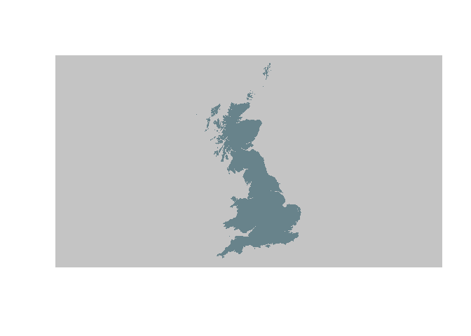

```r
plot(gla, bg="grey77", col="lightblue4", border=NA)
```

We can look at the attributes using `summary`.

```r
summary(gla)
```

```
## Object of class SpatialPolygonsDataFrame
## Coordinates:
##        min       max
## x 5513.000  655604.7
## y 5337.901 1220301.5
## Is projected: TRUE
## proj4string :
## [+proj=tmerc +lat_0=49 +lon_0=-2 +k=0.9996012717 +x_0=400000
## +y_0=-100000 +ellps=airy +units=m +no_defs]
## Data attributes:
##     objectid        lad15cd            lad15nm            lad15nmw
##  Min.   :  1.00   Length:380         Length:380         Length:380
##  1st Qu.: 95.75   Class :character   Class :character   Class :character
##  Median :190.50   Mode  :character   Mode  :character   Mode  :character
##  Mean   :190.50
##  3rd Qu.:285.25
##  Max.   :380.00
##    st_areasha          st_lengths
##  Min.   :2.904e+06   Min.   :   9250
##  1st Qu.:8.626e+07   1st Qu.:  63487
##  Median :2.644e+08   Median : 114961
##  Mean   :6.054e+08   Mean   : 192971
##  3rd Qu.:6.098e+08   3rd Qu.: 197695
##  Max.   :2.616e+10   Max.   :5250326
```

For these `SpatialPolygonsDataFrame` objects we need the data stored in (not ironically) `gla@data`. These are the regions, and the attributes will include their names and so on.

### Tidy data

However, it would be nice if `ggplot` could be used, and we can `tidy` the data into a long-form dataframe. Once in this form we can manipulate as we want without having to learn much about spatial objects. This turns out to be enough for our purposes

Looking at the read-out above, each of the 380 regions have some metadata associated, which are contained in each of the listed attributes. It should be obvious that `objectid` is just a sequence from 1 to 380. `lad15nm` turns out to be a list of names of the regions – I suspect `lad` for Local Authority District, `15` for 2015 and `nm` for name – and it is easy to specify this as the name to use for the region when using `tidy`.

```r
glat <- tidy(gla, region="lad15nm")
head(glat)
```

```
## # A tibble: 6 x 7
##      long     lat order hole  piece group           id
##     <dbl>   <dbl> <int> <lgl> <fct> <fct>           <chr>
## 1 385774. 815840.     1 FALSE 1     Aberdeen City.1 Aberdeen City
## 2 385778. 815812.     2 FALSE 1     Aberdeen City.1 Aberdeen City
## 3 385776. 815762.     3 FALSE 1     Aberdeen City.1 Aberdeen City
## 4 385760. 815622.     4 FALSE 1     Aberdeen City.1 Aberdeen City
## 5 385758. 815564.     5 FALSE 1     Aberdeen City.1 Aberdeen City
## 6 385770. 815505.     6 FALSE 1     Aberdeen City.1 Aberdeen City
```

Without specifying this the values of `id` (and `group`) are determined numerically beginning at 0, because none of the attributes are necessarily the right name.

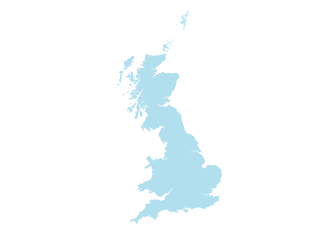

```r
glat %>%
  ggplot(aes(x=long, y=lat, group=group)) +
    geom_polygon(fill="lightblue2", colour=NA, show.legend=FALSE) +
    theme_void() +
    coord_equal()
```

Now this can be plotted using `ggplot`, using `long` and `lat` as the $x$ and $y$ coordinates. The choice of fill colour is determined by `fill` and we can set the colour of the lines by `colour` (or `color`). The two extra arguments are for a suitable blank style and to impose an appropriate ratio of height to width.

Immediately, the awkward shape of the British Isles is apparent. (Note this is a plot of Great Britain, and there is no Northern Ireland.) The islands to the far north are somewhat unnecessary, although quite rightly the inhabitants get a bit tired of being left off maps! Nonetheless I’ll do exactly the same by filtering out the polygons associated with `Orkney Islands` and `Shetland Islands`.

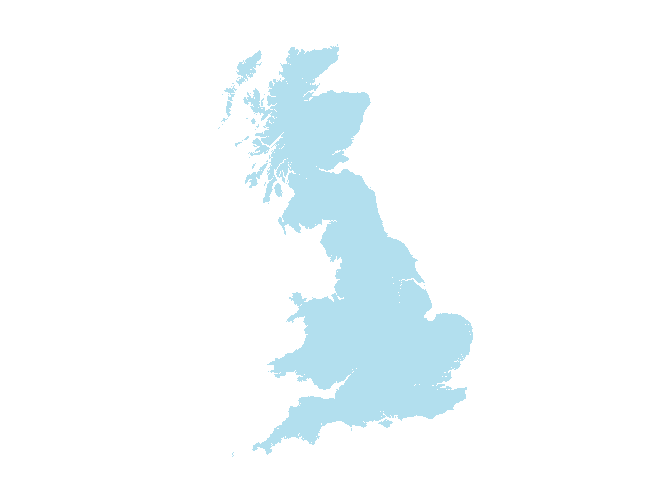

```r
glat %>%
  filter(id != "Orkney Islands", id != "Shetland Islands") %>%
  ggplot(aes(x=long, y=lat, group=group)) +
    geom_polygon(fill="lightblue2", colour=NA, show.legend=FALSE) +
    theme_void() +
    coord_equal()
```

Fewer Scottish Islands makes the graphs a lot clearer with little loss of information, given the tiny number of transactions in the Orkneys and the Shetlands, very far to the north.

### LA boundaries

You may have noticed, one thing that that’s missing on all of these graphs is the Local Authority boundaries. They aren’t, they’re just invisible. That’s because I have set `colour = NA` in all the graphs above, so we can fix that by choosing a colour and making the lines very thin so they don’t swamp the map.

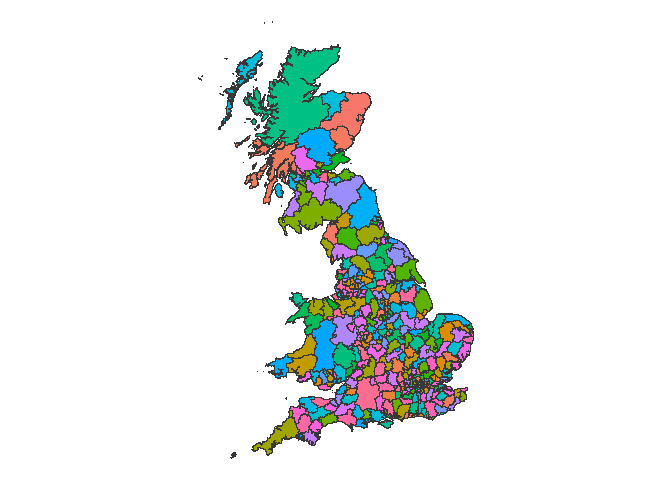

```r
glat %>%
  filter(id != "Orkney Islands", id != "Shetland Islands") %>%
  ggplot(aes(x=long, y=lat, group=group)) +
    geom_polygon(aes(fill=id), colour="grey22", size=0.005, show.legend=FALSE) +
    theme_void() +
    coord_equal()
```

One further amendment, the `fill` is moved inside the `aes()` specification and made conditional. `R` now chooses unique colours for each of the regions.

Two things now need to be done to get the map colours right to illustrate regional inflation rates. First we need to amalgamate some of the Local Authority boundaries to the Land Registry definitions, and second we need to assign the inflation rate to each area.

### Inflation data and regions

We have a map, and we have that data in a form that is easy to understand. If we can suitably attach an inflation rate to each area then we can fill the individual areas with a colour unique to each individual inflation rates.

Recall that the Land Registry areas aren’t quite what we have, and will need amalgamating. Bahaj, Foulis, and Pinter (2020) supplied me the areas that needed amalgamating (and the inflation rates) using the [ONS codes](https://en.wikipedia.org/wiki/ONS_coding_system). This is contained in the metadata `lad15cd` above.

The data is structured in ‘wide’ format with one row for each Land Registry region. The details aren’t very important for us now, but what it means is I can manipulate it to get

```r
# Price data by Land Registry region, converted to long format
gg <- read_excel("house_price_data_figure_1.xls")  %>%
  select("land_reg_region", starts_with("e_"), starts_with("av_")) %>%
  pivot_longer(names_to = "name",
               values_to = "code",
               cols= c(-land_reg_region, -starts_with("av_"))) %>%
  drop_na() %>%
  select("land_reg_region", "code", starts_with("av_"))
head(gg)
```

```
## # A tibble: 6 x 5
##   land_reg_region    code    av_hp_growth_02_~ av_hp_growth_07~ av_hp_growth_09~
##   <chr>              <chr>               <dbl>            <dbl>            <dbl>
## 1 barkinganddagenham E09000~             11.4            -14.0              5.24
## 2 barnet             E09000~              8.41            -8.45             6.95
## 3 barnsley           E08000~             15.9             -9.61            -2.26
## 4 bathandnortheasts~ E06000~             10.3            -12.1              4.60
## 5 bedford            E06000~              9.98           -12.6              2.78
## 6 bexley             E09000~              9.13           -10.5              5.21
```

The important thing that the `pivot_longer` achieves is that for every `land_reg_region` I get a list of all the ONS codes that makes up the Local Authority level. So if I look at `buckinghamshire` as an example there are four ONS codes now associated with it.

```r
filter(gg, land_reg_region == "buckinghamshire")
```

```
## # A tibble: 4 x 5
##   land_reg_region code      av_hp_growth_02_07 av_hp_growth_07~ av_hp_growth_09~
##   <chr>           <chr>                  <dbl>            <dbl>            <dbl>
## 1 buckinghamshire E07000004               8.31            -11.8             4.84
## 2 buckinghamshire E07000005               8.31            -11.8             4.84
## 3 buckinghamshire E07000006               8.31            -11.8             4.84
## 4 buckinghamshire E07000007               8.31            -11.8             4.84
```

Now create a dataframe from `gla$data` which just has the codes and associated names at the Local Authority level:

```r
# Region names used to rearrange Land Registry data
dd <- select(gla@data, code=lad15cd, name=lad15nm)
head(dd)
```

```
##        code                 name
## 0 E06000001           Hartlepool
## 1 E06000002        Middlesbrough
## 2 E06000003 Redcar and Cleveland
## 3 E06000004     Stockton-on-Tees
## 4 E06000005           Darlington
## 5 E06000006               Halton
```

These are necessarily in the same order as the regions in `gla`. Joining the two frames together – `dd` first – by the ONS codes, as in

```r
# Join polygons defined by Land Registry regions
mcodes <- left_join(dd, gg, by=c("code"))
```

produces a match between the Land Registry and the Local Authority areas, plus the inflation rates. To illustrate this just filter out the `buckinghamshire` ones again to see:

```r
filter(mcodes, land_reg_region == "buckinghamshire")
```

```
##        code           name land_reg_region av_hp_growth_02_07
## 1 E07000004 Aylesbury Vale buckinghamshire           8.305245
## 2 E07000005       Chiltern buckinghamshire           8.305245
## 3 E07000006    South Bucks buckinghamshire           8.305245
## 4 E07000007        Wycombe buckinghamshire           8.305245
##   av_hp_growth_07_09 av_hp_growth_09_14
## 1          -11.82091           4.839052
## 2          -11.82091           4.839052
## 3          -11.82091           4.839052
## 4          -11.82091           4.839052
```

Now I can use `unionSpatialPolygons` from the `maptools` library, just supplying the 380-element-long `mcodes$land_reg_region` to create a new `length(unique(mcodes$land_reg_region))` element regional map.

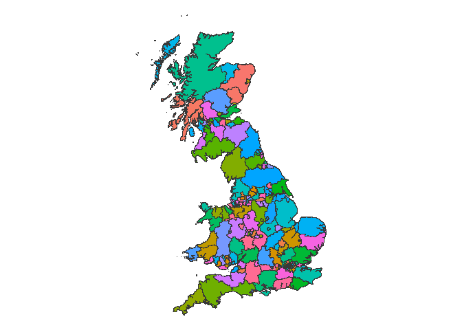

```r
glalrt <- gla %>%
  unionSpatialPolygons(mcodes$land_reg_region) %>%
  tidy() %>%
  filter(id != "orkneyislands", id != "shetlandislands")

glalrt %>%
  ggplot(aes(x=long, y=lat, group=group)) +
    geom_polygon(aes(fill=id), colour="grey22", size=0.005, show.legend=FALSE) +
    theme_void() +
    coord_equal()
```

## Inflation in grayscale

All the information required to plot the Land Registry-based regional inflation rates is now available. As you can see from the `buckinghamshire` data above, there are three average rates in three different periods, so I’ll focus on one, 2002-2007 to begin with.

First, augment the geographic data with the inflation data, and call them something better.

```r
glalrta <- glalrt %>%
  left_join(select(mcodes, id="land_reg_region", starts_with("av_")), by=c("id")) %>%
  rename_at(vars(starts_with("av_hp")), ~ c("Growth 02-07", "Growth 07-09", "Growth 09-14"))
```

Then calculate some limits for the gradient, and modify the specify a plot to include specifically gray and put the legend at the bottom.

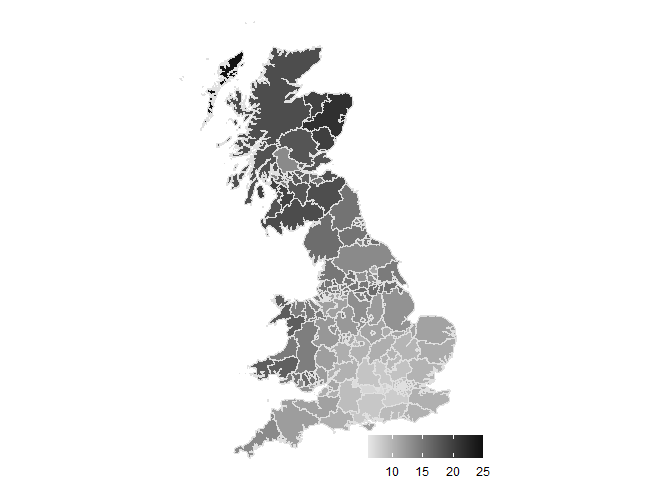

```r
low <- floor(min(glalrta$`Growth 02-07`, na.rm = TRUE))
hig <- ceiling(max(glalrta$`Growth 02-07`, na.rm = TRUE))

# Plot whole GB (minus the islands removed above)
plt <- glalrta %>%
  ggplot(aes(x=long, y=lat, group=group)) +
  geom_polygon(aes(fill=`Growth 02-07`), size=0.005, colour="grey88", show.legend=TRUE) +
  theme_void() +
  coord_equal() +
  scale_fill_gradient(low=grey(0.9), high=grey(0.05), limits=c(low, hig)) +
  theme(legend.direction = "horizontal",
        legend.position  = c(0.75,0.05),
        legend.title     = element_blank()) +
    expand_limits(x = 740000)
plot(plt)
```

## Adding detail

Urban areas have a lot higher population density, and Scotland in the north contains considerably fewer people and properties than the urban north west of England. People tend to be very interested in London, but that is a relatively small part of Great Britain,

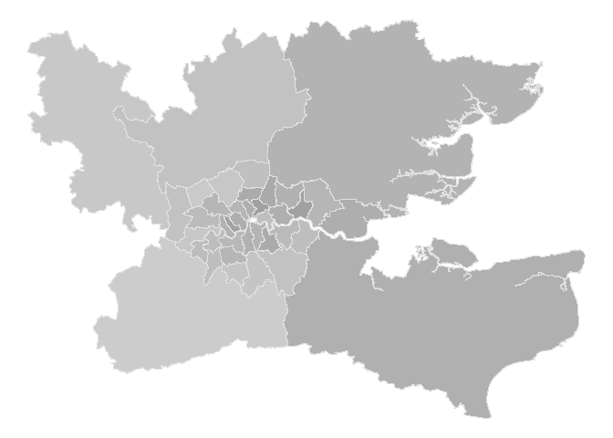

```r
xl    <- c(505000, 555000)
yl    <- c(152500, 202500)
justl <- filter(glalrta, long <= xl[2] & long >= xl[1] & lat <= yl[2] & lat >= yl[1])
justl <- filter(glalrta, id %in% unique(justl$id))

lon   <- ggplot(data=justl, aes(x=long, y=lat, group=group)) +
  geom_polygon(aes(fill=`Growth 02-07`), size=0.005, colour="grey88", show.legend=FALSE) +
  theme_void() +
  scale_fill_gradient(low=grey(0.9), high=grey(0.05), limits=c(low, hig))
lon
```

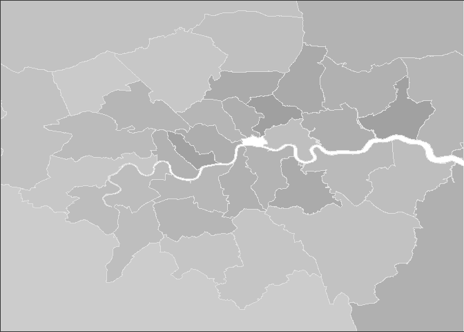

```r
lon   <- ggplot(data=justl, aes(x=long, y=lat, group=group)) +
  geom_polygon(aes(fill=`Growth 02-07`), size=0.005, colour="grey88", show.legend=FALSE) +
  theme_void() +
  scale_fill_gradient(low=grey(0.9), high=grey(0.05), limits=c(low, hig)) +
  coord_cartesian(xlim=xl, ylim=yl, expand=FALSE) +
  theme(panel.border = element_rect(linetype=1, colour="grey22", fill=NA))
lon
```

```r
longrob <- ggplotGrob(lon)
```

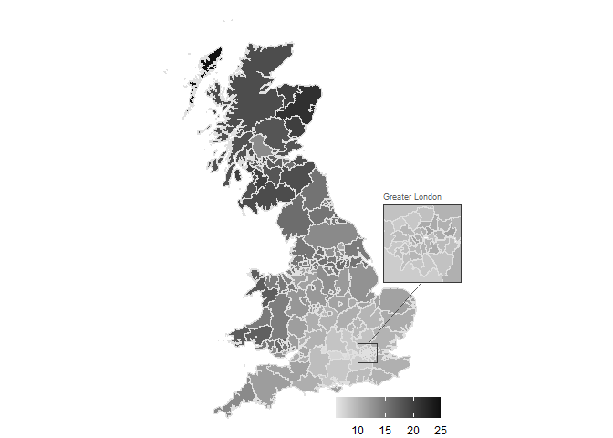

```r
xminl <- xl[1] +  65000
yminl <- yl[1] + 207500
sxl   <- 4*(xl[2] - xl[1])
syl   <- 4*(yl[2] - yl[1])

long.lon    <- c(xl[1], xl[2], xl[2], xl[1])
lat.lon     <- c(yl[1], yl[1], yl[2], yl[2])
latlong.lon <- data.frame(long.lon, lat.lon, grp=c(1,1,1,1)) # Dummy group data

plt2 <- plt +
  annotation_custom(grob=longrob, xmin=xminl, xmax=xminl+sxl, ymin=yminl, ymax=yminl+syl) +
  geom_polygon(data=latlong.lon, aes(long.lon, lat.lon, group=grp),
               fill=NA, color="grey22", linetype=1, size=0.025, alpha=0.8) +
  annotate("segment", x = xl[1] + (xl[2]-xl[1])/2, y = yl[2], xend = xminl + sxl/2, yend = yminl,
           colour = "grey22", size=0.3, alpha=0.8) +
  annotate("text", x = xminl, y= yminl + syl, label = "Greater London",
           colour = "grey22", size=2.5, alpha=0.8, hjust=0, vjust=-0.7)
plt2
```

```r
# Birmingham inset
xb    <- c(370000, 430000)
yb    <- c(260000, 320000)

justb <- filter(glalrta, long <= xb[2] & long >= xb[1] & lat <= yb[2] & lat >= yb[1])
justb <- filter(glalrta, id %in% unique(justb$id))

xminb <- xb[1] - 345000
yminb <- yb[1]
sxb   <- 3*(xb[2] - xb[1])
syb   <- 3*(yb[2] - yb[1])
long.bir    <- c(xb[1], xb[2], xb[2], xb[1])
lat.bir     <- c(yb[1], yb[1], yb[2], yb[2])
latlong.bir <- data.frame(long.bir, lat.bir, grp=c(1,1,1,1))

# Birmingham grob
bir <- ggplot(data=justb, aes(x=long, y=lat, group=group)) +
  geom_polygon(aes(fill=`Growth 02-07`), size=0.025, colour="grey88", show.legend=FALSE) +
  theme_void() +
  coord_cartesian(xlim=xb, ylim=yb, expand=FALSE) +
  scale_fill_gradient(low = grey(0.9), high = grey(0.05), limits = c(low, hig)) +
  theme(panel.border = element_rect(linetype=1, colour="grey22", fill = NA))
birgrob <- ggplotGrob(bir)

# NW inset
xnw    <- c(330000, 410000)
ynw    <- c(375000, 420000)

justnw <- filter(glalrta, long <= xnw[2] & long >= xnw[1] & lat <= ynw[2] & lat >= ynw[1])
justnw <- filter(glalrta, id %in% unique(justnw$id))

xminnw <- xnw[1] + 115000
yminnw <- ynw[1] + 260000
sxnw   <- 3*(xnw[2] - xnw[1])
synw   <- 3*(ynw[2] - ynw[1])
long.nw    <- c(xnw[1], xnw[2], xnw[2], xnw[1])
lat.nw     <- c(ynw[1], ynw[1], ynw[2], ynw[2])
latlong.nw <- data.frame(long.nw, lat.nw, grp=c(1,1,1,1))

# North west grob
nw     <- ggplot(data=justnw, aes(x=long, y=lat, group=group)) +
  geom_polygon(aes(fill=`Growth 02-07`), size=0.025, colour="grey88", show.legend=FALSE) +
  theme_void() +
  coord_cartesian(xlim = xnw, ylim = ynw, expand=FALSE) +
  scale_fill_gradient(low = grey(0.9), high = grey(0.05), limits = c(low, hig)) +
  theme(panel.border = element_rect(linetype=1, colour="grey22", fill = NA))
nwgrob <- ggplotGrob(nw)
```

All of the inserts together look like this:

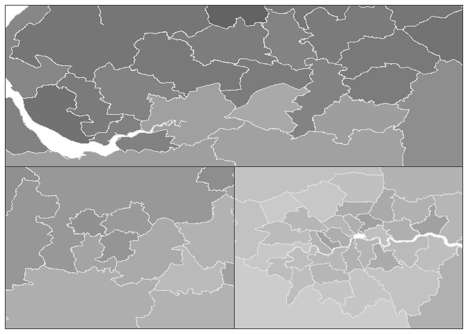

```r
library(patchwork)
nw/(bir+lon)
```

## All together

Finally, we can add the other two grobs and suitable annotation.

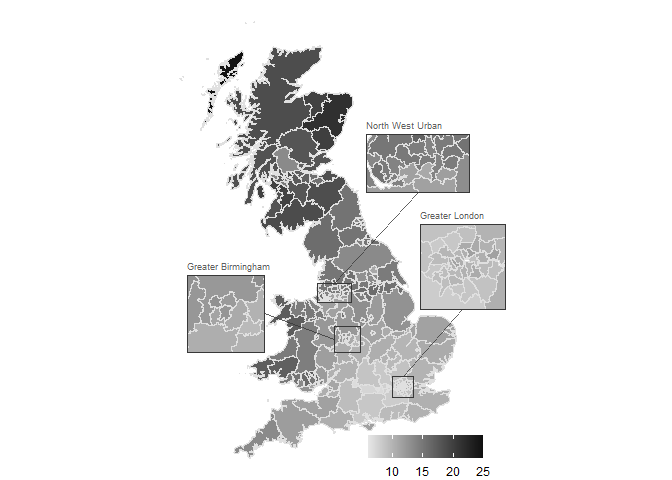

```r
plt3 <- plt2 +
    ## Birmingham
    annotation_custom(grob=birgrob, xmin=xminb, xmax=xminb+sxb, ymin=yminb, ymax=yminb+syb) +
    geom_polygon(data=latlong.bir, aes(long.bir, lat.bir, group=grp),
                 fill=NA, color="grey22", linetype=1, size=0.3, alpha=0.8) +
    annotate("segment", x=xb[1], y=yb[1]+(yb[2]-yb[1])/2, xend=xminb+sxb, yend=yminb+syb/2,
             colour = "grey22", size=0.3, alpha=0.8) +
    annotate("text", x=xminb, y=yminb+syb,label="Greater Birmingham",
             colour = "grey22", size=2.5, alpha=0.8, hjust=0, vjust=-0.7) +
    ## NW
    annotation_custom(grob=nwgrob, xmin=xminnw, xmax=xminnw+sxnw, ymin=yminnw, ymax=yminnw+synw) +
    geom_polygon(data=latlong.nw, aes(long.nw, lat.nw, group=grp),
                 fill=NA, color="grey22", linetype=1, size=0.3, alpha=0.8) +
    annotate("segment", x=xnw[1]+(xnw[2]-xnw[1])/2, y=ynw[2], xend=xminnw+sxnw/2, yend=yminnw,
             colour = "grey22", size=0.3, alpha=0.8) +
    annotate("text", x=xminnw, y=yminnw + synw, label = "North West Urban",
             colour = "grey22", size=2.5, alpha=0.8, hjust=0, vjust=-0.7)

plt3
```

## The real thing

[figure not shown]

## References

Bahaj, Saleem, Angus Foulis, and Gabor Pinter. 2020. “Home Values and Firm Behavior.” *American Economic Review* 110 (7): 2225–70.